# Tips annotated with growth temperature and coding genes/genome size

2024-08-21

There are 23,501 tips in the tree, including genera inserted with zero-length branches:

```
## [1] 23501
```

Most of the tips correspond to species but there are some strains as well:

```
## # A tibble: 7 × 2
##   Rank                n
##   <chr>           <int>
## 1 species         17318
## 2 genus            3710
## 3 strain           2172
## 4 subspecies        274
## 5 no rank            24
## 6 forma specialis     2
## 7 isolate             1
```

All tip labels in the LTP tree have names indicating an accession number, e.g. *Salmonella_enterica_subsp._enterica-_-AE006468–_LT2_T*.

I got he taxids from that accession number, e.g., *99287*.

These taxids were used for mapping the annotations in bugphyzz to the tips in the LTP tree.

```
## Rows: 19,791
## Columns: 3
## $ tip_label <chr> "Salmonella_enterica_subsp._enterica-_-AE006468--_LT2_T", "S…
## $ accession <chr> "AE006468", "AF008580", "MK942857", "EU014680", "EU014684", …
## $ taxid     <chr> "99287", "59203", "576", "59207", "59205", "59202", "59204",…
```

If we look at the number of annotations per dataset before any propagation is done, we see that we only have less than 5,000 annotations for genome size and coding genes. On the the other hand, we have more than 50,000 annotations for growth temperature:

```
## $`coding genes`
## [1] 4669
##
## $`genome size`
## [1] 4665
##
## $`growth temperature`
## [1] 50669
```

When the annotations are mapped to the taxids in the tree, the percentage of annotated tips is quite similar:

```
## $`coding genes`
## [1] 6.16144
##
## $`genome size`
## [1] 6.157185
##
## $`growth temperature`
## [1] 10.6038
```

Even when there are so many annotations for growth temperature (mostly strains from BacDive), they cannot be mapped to the LTP tree without a taxid:

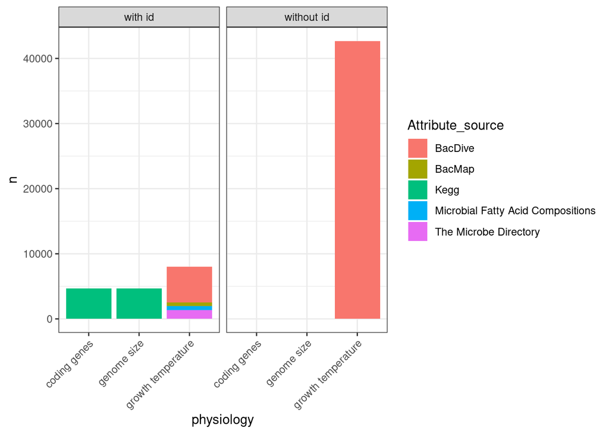

So, after getting a consensus annotation for the species of the strains without taxid, now a good number of species can be mapped to the tree:

```
## $`growth temperature`
## [1] 61.21442
##
## $`coding genes`
## [1] 6.076337
##
## $`genome size`
## [1] 6.072082
```

We can see that the number of taxa with ID now is much greater for growth temperature:

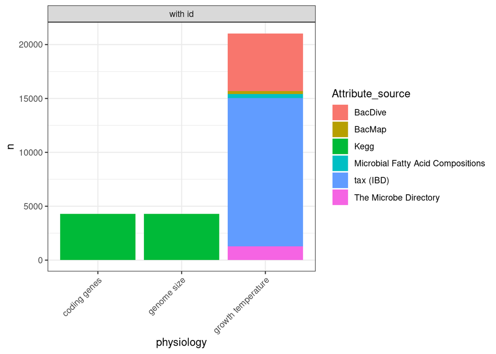